Ying Wei Li

# Project Context

Goal : Explore the finte sequence of $$f(x)=\left\{ \begin{array}{11}\frac{x}{2} \quad \quad \quad \text{, if x is even}\\{3x+1} \quad \quad \negthickspace\negthickspace \negthickspace \text{, if x is odd} \end{array}\right.$$

\ A finite sequence is a sequence that ends. We will explore the sequence of if x is even, x = x/2 and if x is odd x = 3x+1. The sequence will end if x is equal to 1

\ Things that I will explore in this project is the following :

1. Find a pattern where the length of the sequence increases by 1
2. Find a pattern in the first element in the sequence of even and odd numbers
3. Find the longest possible sequence length
4. Find a pattern for all the sequences
5. Find out if prime and non prime numbers have something to do with sequence length

```python
#Exercise 1. Write a Python function single_step(x) that implements the
#function described in 1. above. This function will compute a single step of the sequence
def single_step(x):
    x = float(x)
    if(x <1):
        return None
    if( x==1.0):
        print("1")
        return 1.0
    if (x%2 == 0):
        x = float(x/2)
        return x
    if (x%2 ==1):
        x = float(3*x+1)
        return x
#test exercise 1
p = single_step(5)
print(p)
```

```
16.0
```

```python
#exercise 2
def full_sequence(x):
    arr = []
    while x !=1:
        x = single_step(x)
        if(x != None):
            arr.append(x)
        else:
            return None
    return arr
#test exercise 2
p = full_sequence(5)
print(p)
```

```
[16.0, 8.0, 4.0, 2.0, 1.0]
```

# Section one

Goal : I wanted to see the numbers that will lead to the sequence's length to increase by one

```python
#Function that gets the sequence from x to y
def getSeq(x,y):
    #empty list to store sequence
    los = []
    #empty list to store number
    lon = []
    #loop from x to y
    for i in range (x,y+1):
        #get the sequence of i
        seq = full_sequence(i)
        #if the sequence is not None then add it to it's respected list
        if(seq !=None):
            los.append(full_sequence(i))
            lon.append(i)
    #return the 2 list
    return los,lon
```

**Define getSeq(x,y)** getSeq(x,y) is a function that takes in 2 variables, x and y and returns a list of full_sequences of each number from x to y along with its number in los,lon respectively

```python
#Function that Finds the pattern for increasing sequence length by 1
def increasingSequenceLength(x,y):
    #gets the list of sequence and numbers
    los,lon = getSeq(x,y)
    #to store the seq, number, and length of seq
    pattern1 =[]
    #counter to hold the value of the current length to look for
    holder = 0
    for i in range (len(los)):
        #if the length is equal to the holder value add it to pattern1 and find the next seq to the pattern
        if(len(los[i]) == holder):
            arrToAdd = []
            arrToAdd.append(los[i])
            arrToAdd.append(lon[i])
            arrToAdd.append(len(los[i]))
            pattern1.append(arrToAdd)
            holder = holder +1
    return pattern1
```

**Define increasingSequenceLength(x,y)** \ This function returns a list of a list of sequences as well as its length between x and y

**Exploration 1** Here is where I explore using the increasingSequenceLength function to explore what type of numbers will cause the sequence length to increase by one every single time.

```python
import matplotlib.pyplot as plt
import numpy as np

#print out the pattern of increasing sequence length
pattern1 = increasingSequenceLength(0,1024)
listOfLengthToPlot = []
numToPlot = []
for i in range (len(pattern1)):
    sequence = pattern1[i][0]
    number = pattern1[i][1]
    lengthOfSequence = pattern1[i][2]
    listOfLengthToPlot.append(pattern1[i][2])
    numToPlot.append(pattern1[i][1])
    print("seq = {seq}, num = {num}, length of sequence = {len}".format(seq=sequence, num=number, len= lengthOfSequence))
```

```
seq = [], num = 1, length of sequence = 0
seq = [1.0], num = 2, length of sequence = 1
seq = [2.0, 1.0], num = 4, length of sequence = 2
seq = [4.0, 2.0, 1.0], num = 8, length of sequence = 3
seq = [8.0, 4.0, 2.0, 1.0], num = 16, length of sequence = 4
seq = [16.0, 8.0, 4.0, 2.0, 1.0], num = 32, length of sequence = 5
seq = [32.0, 16.0, 8.0, 4.0, 2.0, 1.0], num = 64, length of sequence = 6
seq = [64.0, 32.0, 16.0, 8.0, 4.0, 2.0, 1.0], num = 128, length of sequence = 7
seq = [128.0, 64.0, 32.0, 16.0, 8.0, 4.0, 2.0, 1.0], num = 256, length of sequence = 8
seq = [256.0, 128.0, 64.0, 32.0, 16.0, 8.0, 4.0, 2.0, 1.0], num = 512, length of sequence = 9
seq = [512.0, 256.0, 128.0, 64.0, 32.0, 16.0, 8.0, 4.0, 2.0, 1.0], num = 1024, length of sequence = 10
```

This code is used to print out the sequence in increasing length order

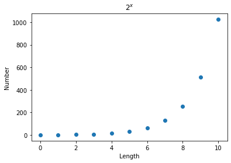

```python
#grath to show how the length
xpoints = listOfLengthToPlot
ypoints = numToPlot
plt.title("$2^x$")
plt.plot(xpoints, ypoints,'o')
plt.xlabel("Length")
plt.ylabel("Number")
plt.show()
```

# Result one

\ I made a function called increasingSequenceLength that would print out the sequence, number, and length of sequence in increasing seq length order. What I noticed from this is that everytime the sequence length increases by 1, it is to a power of 2.

Ex = \ $\quad $ Length of full_sequence(1) = 0, $\enspace2^0$ = 1 \ $\quad $ Length of full_sequence(2) = 1, $\enspace2^1$ = 2 \ $\quad $ Length of full_sequence(4) = 2, $\enspace2^2$ = 4 \ $\quad $ Length of full_seuqence(8) = 3, $\enspace2^3$ = 8 \ $\quad $ ETC \ \ Another thing that I noticed is that the sequence also contains the power of 2's in reverse order. The sequence contains the power of 2 of everything that is under $2^{Sequence Length}$ \ \ Ex = \ $\quad $ seq = [], num = 1, length of sequence = 0 \ $\quad $ seq = [1.0], num = 2, length of sequence = 1 \ $\quad $ seq = [2.0, 1.0], num = 4, length of sequence = 2 \ $\quad $ seq = [4.0, 2.0, 1.0], num = 8, length of sequence = 3 \ $\quad $ seq = [8.0, 4.0, 2.0, 1.0], num = 16, length of sequence = 4 \ $\quad $... \ $\quad $ seq = [256.0, 128.0, 64.0, 32.0, 16.0, 8.0, 4.0, 2.0, 1.0], num = 512, length of sequence = 9

# Section Two

Goal: Print out the first index of all even numbers of the sequence to find a common pattern

```python
#function to get all the first index of even number sequence
def getAllEvenSeq(x,y):
    #gets the sequence of x to y
    los,lon = getSeq(x,y)
    #list for even number sequences
    listOfEvenSeq=[]
    #list of even numbers
    lofEven = []
    #length of the sequence
    length = []
    for i in range (len(los)):
        #mod it by 2 to see if it is even, if it is add it to its respective array
        if(lon[i]%2==0):
            ##add the first index of the sequence
            listOfEvenSeq.append(los[i][0])
            lofEven.append(lon[i])
            length.append(len(los[i]))
    return listOfEvenSeq, lofEven, length
```

**Define getAllEvenSeq** \ This function returns all even sequences between x and y as well as its length and number that got the sequence

**Explore 2** Explore what happens when you print out all the first indexes of sequence of even numbers

[figure not shown]

```python
#prints out the first index of even numbers
allevenSeq, listOfEven, evenLength = getAllEvenSeq(1,200)
#for a in range (len(allevenSeq)):
#    print("The First index of full_sequence({num}) is {allEvenSeq}, length of sequence is {length}".format(num= listOfEven[a], allEvenSeq=allevenSeq[a], length = evenLength[a]))
plt.title("Value of first element in even number Sequence")
plt.plot(allevenSeq, listOfEven,'o')
plt.xlabel("Even Numbers")
plt.ylabel("Sequence Length")
plt.show()
```

**Explore 2** \ Look at the length of all even number sequence lengths

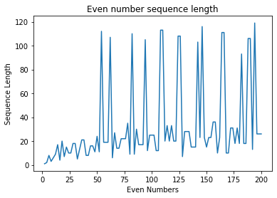

```python
plt.title("Even number sequence length")
plt.plot(listOfEven, evenLength)
plt.xlabel("Even Numbers")
plt.ylabel("Sequence Length")
plt.show()
```

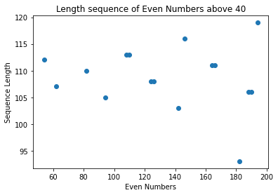

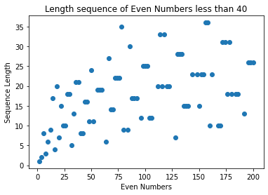

```python
#holds sequnce length of even numbers greater than 40
listOfEvenGreaterThan40 =[]
#holds the even number associated with listOfEvenGreaterThan40
listOfevenNumber = []
#holds sequnce length of even numbers less than 40
listOfEvenLessThan40 = []
#holds the even number associated with listOfEvenLessThan40
listOfEvenNumbers2 = []
#loop through list of even number sequence
for i in range (len(listOfEven)):
    #if it is greater than 40 add it to listOfEvenGreaterThan40 and listOfevenNumber
    if(evenLength[i] >40):

        listOfEvenGreaterThan40.append(evenLength[i])

        listOfevenNumber.append(listOfEven[i])
    else:
        #if it is less than 40 add it to listOfEvenLessThan40 and listOfEvenNumbers2
        listOfEvenLessThan40.append(evenLength[i])
        listOfEvenNumbers2.append(listOfEven[i])

plt.title("Length sequence of Even Numbers above 40")
plt.plot(listOfevenNumber, listOfEvenGreaterThan40,'o')
plt.xlabel("Even Numbers")
plt.ylabel("Sequence Length")
plt.show()

plt.title("Length sequence of Even Numbers less than 40")
plt.plot(listOfEvenNumbers2, listOfEvenLessThan40,'o')
plt.xlabel("Even Numbers")
plt.ylabel("Sequence Length")
plt.show()
```

```python
#function to get all the odd number sequence
def getAllOddSeq(x,y):
    #get sequence x to y
    los,lon = getSeq(x,y)
    #list of all odd sequence
    listOfOddSeq=[]
    #list of odd number
    lofOdd = []
    #length of the sequence
    lengthOfOdd = []
    for i in range (len(los)):
        #mod it by 2 to see if it is odd and add it to its respective array
        if(lon[i]%2==1):
            listOfOddSeq.append(los[i])
            lofOdd.append(lon[i])
            lengthOfOdd.append(len(los[i]))
    return listOfOddSeq, lofOdd, lengthOfOdd
```

**Define getAllOddSeq(x,y)** This function returns all odd sequences between x and y as well as its length and number that got the sequence

**Explore 2** \ Look at the length of all odd number sequence lengths

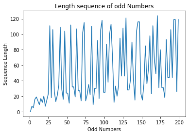

```python
listOfOddSeq, lofOdd, lengthOfOdd = getAllOddSeq(0,200)
plt.title("Length sequence of odd Numbers")
plt.plot(lofOdd, lengthOfOdd)
plt.xlabel("Odd Numbers")
plt.ylabel("Sequence Length")
plt.show()
```

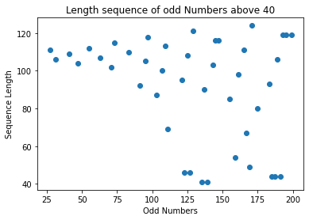

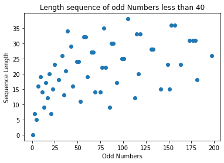

```python
#holds sequnce length of odd numbers greater than 40
listOfOddGreaterThan40 =[]
#holds the odd number associated with listOfOddGreaterThan40
listOfNumber = []
#holds sequnce length of odd numbers less than 40
listOfOddLessThan40 = []
#holds the odd number associated with listOfOddLessThan40
listOfNumbers2 = []
#loop through list of odd number sequence
for i in range (len(listOfOddSeq)):
    #if it is greater than 40 add it to listOfOddGreaterThan40 and listOfNumber
    if(len(listOfOddSeq[i]) >40):
        listOfOddGreaterThan40.append(len(listOfOddSeq[i]))
        listOfNumber.append(lofOdd[i])
    else:
        #if it is less than 40 add it to listOfOddLessThan40 and listOfNumber2
        listOfOddLessThan40.append(len(listOfOddSeq[i]))
        listOfNumbers2.append(lofOdd[i])
plt.title("Length sequence of odd Numbers above 40")
plt.plot(listOfNumber, listOfOddGreaterThan40,'o')
plt.xlabel("Odd Numbers")
plt.ylabel("Sequence Length")
plt.show()

plt.title("Length sequence of odd Numbers less than 40")
plt.plot(listOfNumbers2, listOfOddLessThan40,'o')
plt.xlabel("Odd Numbers")
plt.ylabel("Sequence Length")
plt.show()
```